# **Analyzing Movie Ratings**

Eric Nguyen

2025-04-25

### **General Introduction of the Project**

#### Introduction

In this project, we’ll analyze movie ratings data from IMDb using web scraping techniques in R. We’ll extract information such as titles, release years, runtimes, genres, ratings, and vote counts for the top 30 movies released between March and July 2020.

#### Purpose

Using packages like `rvest` and `dplyr`, we’ll practice loading web pages, identifying CSS selectors, and extracting specific data elements. We’ll also gain experience in data cleaning by handling missing values. Finally, we’ll use `ggplot2` to visualize the relationship between user ratings and number of votes, uncovering trends in movie popularity and reception. This project offers hands-on experience in web scraping, data manipulation, and visualization using R, skills that are highly valuable in real-world data analysis scenarios.

#### Libraries used

`rvest`, `dplyr`, `ggplot2`, `stringr`, `readr`, `tibble`

### **Implementing**

#### Loading libraries

```r
library(rvest)
library(dplyr)
library(ggplot2)
library(stringr)
library(readr)
library(tibble)
```

#### Specifying the URL where we will extract the video datas from

```r
url <- "http://dataquestio.github.io/web-scraping-pages/IMDb-DQgp.html"
```

#### Loading the web page content using the `read_html()` function

```r
web_content <- read_html(url)
```

#### Website Scraping

To scrape this web, we’ll need a strategy. There are some things we can learn from observing the web:

- The blocks from one movie to another are similar; hence, if we can understand a block structure, we’ll likely understand the overall structure.
- There are some missing values. Specially, the ratings and user votes are missing for some movies.

**Movies’ Names**

```r
title_selector <- ".lister-item-header a"
n_title <- 30
titles <- web_content %>%
  html_nodes(title_selector) %>%
  html_text()

titles
```

```
##  [1] "Mulan"
##  [2] "The Call"
##  [3] "Greenland"
##  [4] "Don't Listen"
##  [5] "Unhinged"
##  [6] "Ava"
##  [7] "The Hunt"
##  [8] "Ghosts of War"
##  [9] "Hamilton"
## [10] "The Old Guard"
## [11] "The Secret: Dare to Dream"
## [12] "The Outpost"
## [13] "Extraction"
## [14] "Train to Busan Presents: Peninsula"
## [15] "Greyhound"
## [16] "The King of Staten Island"
## [17] "A Quiet Place Part II"
## [18] "Bloodshot"
## [19] "The Dark and the Wicked"
## [20] "Arkansas"
## [21] "The Rental"
## [22] "Trolls World Tour"
## [23] "Sputnik"
## [24] "Eurovision Song Contest: The Story of Fire Saga"
## [25] "Inheritance"
## [26] "Spenser Confidential"
## [27] "The Tax Collector"
## [28] "The Way Back"
## [29] "The Silencing"
## [30] "Archive"
```

**Movies’ Release Years**

```r
release_year_selector <- ".lister-item-year"
n_release_year <- 30
release_years <- web_content %>%
  html_nodes(release_year_selector) %>%
  html_text()

release_years
```

```
##  [1] "(2020)"      "(2020)"      "(2020)"      "(2020)"      "(2020)"
##  [6] "(IV) (2020)" "(II) (2020)" "(2020)"      "(2020)"      "(2020)"
## [11] "(2020)"      "(2020)"      "(2020)"      "(2020)"      "(2020)"
## [16] "(2020)"      "(2020)"      "(2020)"      "(2020)"      "(2020)"
## [21] "(2020)"      "(2020)"      "(2020)"      "(2020)"      "(I) (2020)"
## [26] "(2020)"      "(2020)"      "(2020)"      "(2020)"      "(2020)"
```

We will convert the years from character to numeric data type.

```r
release_years <- parse_number(release_years)

release_years
```

```
##  [1] 2020 2020 2020 2020 2020 2020 2020 2020 2020 2020 2020 2020 2020 2020 2020
## [16] 2020 2020 2020 2020 2020 2020 2020 2020 2020 2020 2020 2020 2020 2020 2020
```

**Movies’ Runtimes**

```r
runtime_selector <- ".runtime"
n_runtime <- 30
runtimes <- web_content %>%
  html_nodes(runtime_selector) %>%
  html_text()

runtimes
```

```
##  [1] "115 min" "112 min" "119 min" "97 min"  "90 min"  "96 min"  "90 min"
##  [8] "94 min"  "160 min" "125 min" "107 min" "123 min" "116 min" "116 min"
## [15] "91 min"  "136 min" "97 min"  "109 min" "95 min"  "117 min" "88 min"
## [22] "90 min"  "113 min" "123 min" "111 min" "111 min" "95 min"  "108 min"
## [29] "93 min"  "109 min"
```

Since all runtime values are displayed by `min` (minutes), we can remove the time unit and convert the values to numeric data type.

```r
runtimes <- parse_number(runtimes)

runtimes
```

```
##  [1] 115 112 119  97  90  96  90  94 160 125 107 123 116 116  91 136  97 109  95
## [20] 117  88  90 113 123 111 111  95 108  93 109
```

**Movies’ Genres**

```r
genre_selector <- ".genre"
n_genre <- 30
genres <- web_content %>%
  html_nodes(genre_selector) %>%
  html_text()

genres
```

```
##  [1] "\nAction, Adventure, Drama            "
##  [2] "\nHorror, Mystery, Thriller            "
##  [3] "\nAction, Drama, Thriller            "
##  [4] "\nDrama, Horror, Thriller            "
##  [5] "\nAction, Thriller            "
##  [6] "\nAction, Crime, Drama            "
##  [7] "\nAction, Horror, Thriller            "
##  [8] "\nHorror, Thriller, War            "
##  [9] "\nBiography, Drama, History            "
## [10] "\nAction, Adventure, Fantasy            "
## [11] "\nDrama, Romance            "
## [12] "\nAction, Drama, History            "
## [13] "\nAction, Thriller            "
## [14] "\nAction, Horror, Thriller            "
## [15] "\nAction, Drama, History            "
## [16] "\nComedy, Drama            "
## [17] "\nDrama, Horror, Sci-Fi            "
## [18] "\nAction, Drama, Sci-Fi            "
## [19] "\nHorror            "
## [20] "\nCrime, Drama, Thriller            "
## [21] "\nHorror, Thriller            "
## [22] "\nAnimation, Adventure, Comedy            "
## [23] "\nDrama, Horror, Sci-Fi            "
## [24] "\nComedy, Music            "
## [25] "\nDrama, Mystery, Thriller            "
## [26] "\nAction, Comedy, Crime            "
## [27] "\nAction, Crime, Drama            "
## [28] "\nDrama, Sport            "
## [29] "\nAction, Crime, Thriller            "
## [30] "\nDrama, Sci-Fi, Thriller            "
```

There seems to be addition whitespaces at the end of the values. Removing them will be better for future analyzing.

```r
genres <- str_trim(genres)

genres
```

```
##  [1] "Action, Adventure, Drama"     "Horror, Mystery, Thriller"
##  [3] "Action, Drama, Thriller"      "Drama, Horror, Thriller"
##  [5] "Action, Thriller"             "Action, Crime, Drama"
##  [7] "Action, Horror, Thriller"     "Horror, Thriller, War"
##  [9] "Biography, Drama, History"    "Action, Adventure, Fantasy"
## [11] "Drama, Romance"               "Action, Drama, History"
## [13] "Action, Thriller"             "Action, Horror, Thriller"
## [15] "Action, Drama, History"       "Comedy, Drama"
## [17] "Drama, Horror, Sci-Fi"        "Action, Drama, Sci-Fi"
## [19] "Horror"                       "Crime, Drama, Thriller"
## [21] "Horror, Thriller"             "Animation, Adventure, Comedy"
## [23] "Drama, Horror, Sci-Fi"        "Comedy, Music"
## [25] "Drama, Mystery, Thriller"     "Action, Comedy, Crime"
## [27] "Action, Crime, Drama"         "Drama, Sport"
## [29] "Action, Crime, Thriller"      "Drama, Sci-Fi, Thriller"
```

**Movies’ Ratings**

```r
rating_selector <- ".ratings-imdb-rating"
n_rating <- 30
ratings <- web_content %>%
  html_nodes(rating_selector) %>%
  html_text()

ratings
```

```
##  [1] "\n        \n        5.5\n    " "\n        \n        7.2\n    "
##  [3] "\n        \n        6.3\n    " "\n        \n        6.1\n    "
##  [5] "\n        \n        6.0\n    " "\n        \n        5.3\n    "
##  [7] "\n        \n        6.5\n    " "\n        \n        5.5\n    "
##  [9] "\n        \n        8.6\n    " "\n        \n        6.6\n    "
## [11] "\n        \n        6.4\n    " "\n        \n        6.8\n    "
## [13] "\n        \n        6.7\n    " "\n        \n        5.4\n    "
## [15] "\n        \n        7.0\n    " "\n        \n        7.1\n    "
## [17] "\n        \n        5.7\n    " "\n        \n        6.2\n    "
## [19] "\n        \n        5.9\n    " "\n        \n        5.7\n    "
## [21] "\n        \n        6.1\n    " "\n        \n        6.4\n    "
## [23] "\n        \n        6.5\n    " "\n        \n        5.5\n    "
## [25] "\n        \n        6.2\n    " "\n        \n        4.7\n    "
## [27] "\n        \n        6.7\n    " "\n        \n        6.1\n    "
## [29] "\n        \n        6.3\n    "
```

The rating values have extra `\n` texts and whitespaces, so we’ll need to remove them.

```r
ratings <- str_trim(ratings)
ratings <- parse_number(ratings)

ratings
```

```
##  [1] 5.5 7.2 6.3 6.1 6.0 5.3 6.5 5.5 8.6 6.6 6.4 6.8 6.7 5.4 7.0 7.1 5.7 6.2 5.9
## [20] 5.7 6.1 6.4 6.5 5.5 6.2 4.7 6.7 6.1 6.3
```

**Movies’ Metascores**

```r
metascore_selector <- ".metascore"
n_metascore <- 30
metascores <- web_content %>%
  html_nodes(metascore_selector) %>%
  html_text()

metascores
```

```
##  [1] "66        " "40        " "39        " "50        " "38        "
##  [6] "90        " "70        " "32        " "71        " "56        "
## [11] "51        " "64        " "67        " "44        " "72        "
## [16] "55        " "63        " "51        " "61        " "50        "
## [21] "31        " "49        " "22        " "66        " "67        "
```

We’ll remove the extra whitespaces, as well.

```r
metascores <- str_trim(metascores)

metascores
```

```
##  [1] "66" "40" "39" "50" "38" "90" "70" "32" "71" "56" "51" "64" "67" "44" "72"
## [16] "55" "63" "51" "61" "50" "31" "49" "22" "66" "67"
```

**Movies’ Votes**

```r
vote_selector <- ".sort-num_votes-visible :nth-child(2)"
n_vote = 30
votes <- web_content %>%
  html_nodes(vote_selector) %>%
  html_text()

votes
```

```
##  [1] "80,231"  "6,559"   "27,482"  "4,879"   "25,316"  "20,882"  "62,277"
##  [8] "4,886"   "48,663"  "117,211" "5,420"   "17,001"  "151,319" "16,815"
## [15] "60,885"  "29,278"  "57,763"  "3,701"   "7,951"   "13,965"  "14,792"
## [22] "10,516"  "69,186"  "7,837"   "65,768"  "7,416"   "28,300"  "9,355"
## [29] "9,271"
```

We’ll convert those values into numeric data type.

```r
votes <- parse_number(votes)

votes
```

```
##  [1]  80231   6559  27482   4879  25316  20882  62277   4886  48663 117211
## [11]   5420  17001 151319  16815  60885  29278  57763   3701   7951  13965
## [21]  14792  10516  69186   7837  65768   7416  28300   9355   9271
```

#### Handling *missing values*

As usual, we will now combine all the extracted datas into a dataset using `tibble`. However, there are multiple missing values, so this operation will throw an error. Therefore, a handling-missing-values process has to be carried out.

The *metascore* datas are missing a lot. We can handle this by replacing them with `NA values`.

However, appending values into vectors is **not normally possible** in R. Consequently, we will have to implement our own function.

```r
append_vector <- function(vector, inserted_indices, values){

  ## Creating the current indices of the vector
  vector_current_indices <- 1:length(vector)

  ## Adding small amount of values (between 0 and 0.9) to the `inserted_indices`
  new_inserted_indices <- inserted_indices + seq(0, 0.9, length.out = length(inserted_indices))

  ## Appending the `new_inserted_indices` to the current vector indices
  indices <- c(vector_current_indices, new_inserted_indices)

  ## Ordering the indices
  ordered_indices <- order(indices)

  ## Appending the new value to the existing vector
  new_vector <- c(vector, values)

  ## Ordering the new vector wrt the ordered indices
  new_vector[ordered_indices]
}
```

Now, we can easily add the `NA values`.

```r
metascores <- append_vector(metascores, c(1, 1, 1, 13, 24), NA)

metascores
```

```
##  [1] "66" NA   NA   NA   "40" "39" "50" "38" "90" "70" "32" "71" "56" "51" "64"
## [16] "67" NA   "44" "72" "55" "63" "51" "61" "50" "31" "49" "22" "66" NA   "67"
```

Exploring the website again, we notice that the 17th movie is a big problem since it barely has any useful datas. Therefore, we’ll remove the movie.

```r
titles <- titles[-17]
release_years <- release_years[-17]
runtimes <- runtimes[-17]
genres <- genres[-17]
metascores <- metascores[-17]
```

#### Putting everything *altogether*

```r
movie_df <- tibble(titles, release_years, runtimes, genres, metascores)

head(movie_df, 10)
```

```
## # A tibble: 10 × 5
##    titles        release_years runtimes genres                     metascores
##    <chr>                 <dbl>    <dbl> <chr>                      <chr>
##  1 Mulan                  2020      115 Action, Adventure, Drama   66
##  2 The Call               2020      112 Horror, Mystery, Thriller  <NA>
##  3 Greenland              2020      119 Action, Drama, Thriller    <NA>
##  4 Don't Listen           2020       97 Drama, Horror, Thriller    <NA>
##  5 Unhinged               2020       90 Action, Thriller           40
##  6 Ava                    2020       96 Action, Crime, Drama       39
##  7 The Hunt               2020       90 Action, Horror, Thriller   50
##  8 Ghosts of War          2020       94 Horror, Thriller, War      38
##  9 Hamilton               2020      160 Biography, Drama, History  90
## 10 The Old Guard          2020      125 Action, Adventure, Fantasy 70
```

#### Visualizing

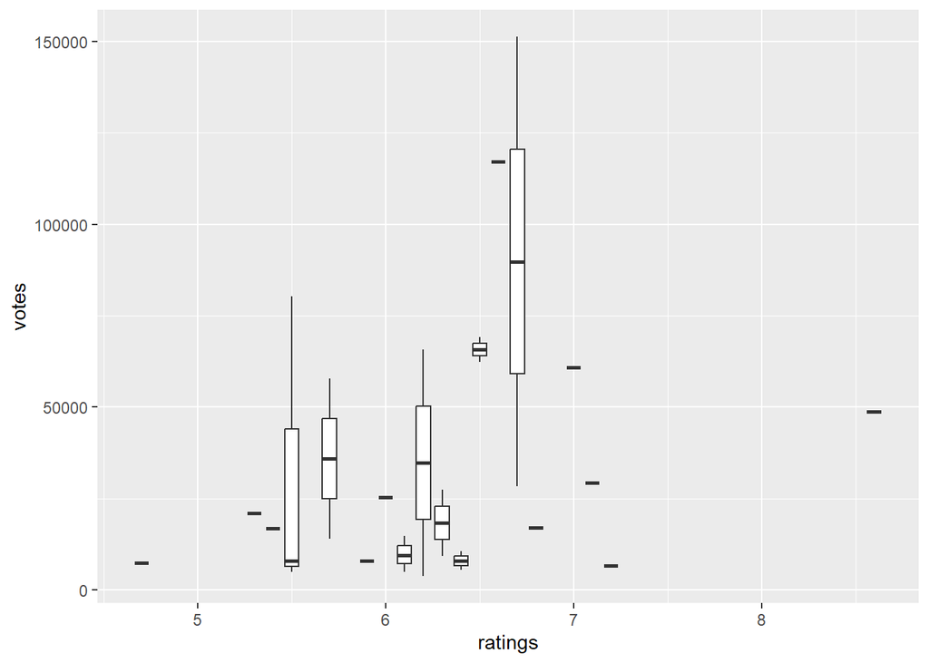

```r
ggplot(data = movie_df,
       aes(x = ratings, y = votes, group = ratings)) +
  geom_boxplot()
```